# Examples for common file prep, plotting, anova, and regression

Michelle Voss

# **Clear previous, load packages**

**This is a “wide format” file with data from our acute exercise manipulation in the bike project**  
* There are 34 participants, 11 variables

```r
# load acute variables data file
data = read.table("exercise_fileprep-plots-anova_data/acute_physio-variables-forR.csv", header=TRUE, sep = ",", fill = TRUE)
# look at features of your variables (encoded as integer, numeric or factors?)
str(data)
```

```
'data.frame':   34 obs. of  11 variables:
 $ bike_id    : int  142 206 202 225 228 223 247 252 270 290 ...
 $ order      : int  1 0 0 1 1 0 1 0 1 1 ...
 $ hr_active  : num  0.68 0.72 0.68 0.74 0.71 0.7 0.73 0.72 0.74 0.73 ...
 $ hr_passive : num  0.54 0.47 0.51 0.52 0.55 0.42 0.43 0.47 0.56 0.6 ...
 $ rpe_active : num  11.6 11.7 12.5 12 12.3 16.2 10.9 11.4 10.9 12.3 ...
 $ rpe_passive: num  11.2 10.8 11.3 8 10.7 8.1 8 9 6.9 10 ...
 $ fs_active  : num  2.9 4.8 3.8 3 2.9 3 5 3 3.25 2.8 ...
 $ fs_passive : num  -1 4.9 3.2 3 4 3 5 3 5 5 ...
 $ fas_active : num  1.4 5 2.2 2 2 3 1 2 1 2 ...
 $ fas_passive: num  2.2 4.1 1.9 2 1.3 3 1 1 1.1 1 ...
 $ subject_id : Factor w/ 33 levels "GEA161","GEA270",..: 26 31 30 27 28 32 29 33 2 3 ...
```

# **Referring to variables in a dataset**

```r
# change hr to percent for clarity of axes
# generic call of variable is dataframe$variable
# read <- as "is given by"
# here we are recoding, rather than making a new variable
data$hr_active <- 100*data$hr_active
data$hr_passive <- 100*data$hr_passive
```

# **Reshaping from wide to long**

- Especially for longitudinal data, long format is much “tidyer”
- One nugget of info fits in each cell and use columns to label attributes of variable values

```r
# reshape is a function to help transform from wide to long
# look at the dataframe to see if you can tell how it's working
# it will not work if the variable name has two delimiters (e.g. notice all variables have only one underscore)
# when you name your variables initially, it's is very helpful to have the variable attribute (e.g., session, condition) following the underscore
data_long<-reshape(data,
                             varying=c(3:10),
                             timevar="condition",
                             direction="long",
                             idvar="bike_id",
                             sep="_")
```

# **Plotting to understand the data**

- label your chunk and any figures will be saved in a directory at low-res for rendering on github or sending to colleagues
- Histograms and boxplots are nice for initial description
- Familiarize with distribution shape (normal or skewed) and anything funky (outliers)

Simple box plot  
* aes <- aesthetics, basic parameters of what to plot from the dataframe  
* generic call: ggplot(dataframe,aes(x=variable-on-x-axis,y=variable-on-y-axis,fill=variable-to-color-code))  
* geom_boxplot() make a boxplot  
* https://ggplot2.tidyverse.org/reference/geom_boxplot.html  
* http://www.sthda.com/english/wiki/ggplot2-box-plot-quick-start-guide-r-software-and-data-visualization  
* geom_point() add points for individuals by making a scatter plot with a factor variable here  
* https://ggplot2.tidyverse.org/reference/geom_point.html

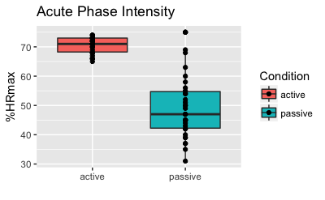

```r
ggplot(data_long, aes(x=condition,y=hr,fill=condition)) +
  geom_boxplot() +
  geom_point() +
  labs(title="Acute Phase Intensity",y="%HRmax",x="",fill="Condition")
```

**GGplot is powerful and can help you add a lot of information to a plot like below**

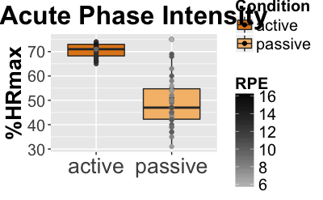

```r
# center title
theme_update(plot.title = element_text(hjust = 0.5))
# ggplot tool
# each parentheses after the + adds a new feature to the plot
ggplot(data_long, aes(x=condition,y=hr,fill=condition)) +
  scale_fill_manual(values=c("#E3871C", "#F5BD78")) +
  geom_boxplot() +
  geom_point(aes(color=rpe)) +
  scale_color_gradient(low="gray",high="black",name="RPE") +
  labs(title="Acute Phase Intensity",y="%HRmax",x="",fill="Condition") +
  geom_text(aes(label=ifelse((hr>(quantile(hr,.75)+3*IQR(hr))|hr<(quantile(hr,.25)-3*IQR(hr))),paste(subject_id),"")), hjust=1.1, check_overlap = TRUE, size=3) +
  theme(title=element_text(size=20, face='bold'),
        axis.text.x = element_text(size=20),
        axis.text.y = element_text(size=15),
        axis.title.y = element_text(size=20),
        legend.text = element_text(size=15),
        legend.title = element_text(size=15))
# save a high-resolution file in your directory for pub-level figures
ggsave("acute-hr.tiff", width = 200, height = 100, units = "mm",dpi=300)
```

**How about a bar graph with error bars?**  
* fun.data=mean_se -> standard error  
* fun.data=mean_cl_normal -> confidence interval  
* Web resources  
* http://murraylax.org/rtutorials/barplots.html

```
The plyr::rename operation has created duplicates for the following name(s): (`size`)Scale for 'y' is already present. Adding another scale for 'y', which will replace the existing scale.
```

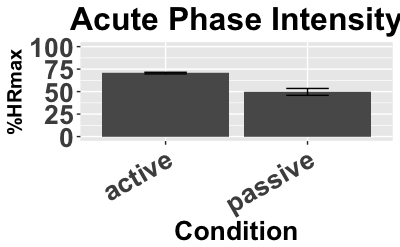

```r
# center title
theme_update(plot.title = element_text(hjust = 0.5))
ggplot(data = data_long, aes(x = condition, y = hr)) +
  stat_summary(aes(y = hr), size=.5, fun.y = mean, geom="bar",size=1) +
  stat_summary(fun.data=mean_cl_normal, geom="errorbar", size=.5,width=.3) +
  labs(title="Acute Phase Intensity",y="%HRmax",x="",fill="Condition")  +
  scale_x_discrete(name="Condition") +
  scale_y_continuous(name = "%HRmax") +
  ylim(0,100) +
  theme(title=element_text(size=20, face='bold'),
        axis.text.x = element_text(size=20,face='bold',angle = 30, hjust = 1),
        axis.text.y = element_text(size=20,face='bold'),
        axis.title.y = element_text(size=15))
```

**Show individuals on one plot**

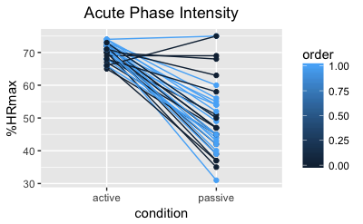

```r
ggplot(data_long, aes(x=condition,y=hr,group=bike_id,color=order)) +
  geom_line() +
  geom_point() +
  labs(title="Acute Phase Intensity",y="%HRmax")
```

**Power of facet wrap to plot by a factor**  
* by variable factor

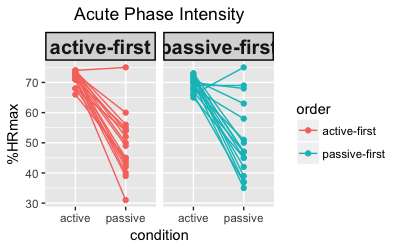

```r
# add labels to a dummy coded factor
data_long$order<-factor(data_long$order,levels=c(1,0),labels=c("active-first","passive-first"))
ggplot(data_long, aes(x=condition,y=hr,group=bike_id,color=order)) +
  geom_line() +
  geom_point() +
  facet_wrap(~order) +
  labs(title="Acute Phase Intensity",y="%HRmax") +
  theme(strip.text = element_text(face="bold", size=15,lineheight=5.0),
        strip.background = element_rect(colour="black", size=1))
```

- by subject

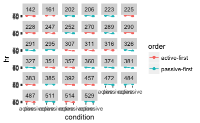

```r
ggplot(data_long, aes(x=condition,y=hr,group=bike_id,color=order)) +
  geom_line() +
  geom_point() +
  facet_wrap(~bike_id)
```

# **Paired t-test**

- nice little tutorial with graphing supplements
- https://rcompanion.org/rcompanion/d_09.html
- for wide format

```r
t.test(data$hr_active,
       data$hr_passive,
       paired=TRUE,
       conf.level=0.95)
```

```
    Paired t-test

data:  data$hr_active and data$hr_passive
t = 10.802, df = 33, p-value = 2.264e-12
alternative hypothesis: true difference in means is not equal to 0
95 percent confidence interval:
 16.97324 24.85029
sample estimates:
mean of the differences
               20.91176
```

- for long format

```r
t.test(hr ~ condition,
       data=data_long,
       paired=TRUE,
       conf.level=0.95)
```

[output not shown]

**ANOVAs**  
* nice little tutorial  
* http://singmann.org/anova-in-r-afex-may-be-the-solution-you-are-looking-for/

- long format

```r
# does hr difference by condition also interact with order of sessions?
library(car)
library(afex)
```

```r
# repeated measures variables specified in error term by subject
# if you had no repeated meaures values you would write: Error(bike_id)
# if you had two repeated meaures values you would write: Error(bike_id/variable1*variable2)
aovHR<-aov_car(hr~condition*order+Error(bike_id/condition),data_long)
```

```
Contrasts set to contr.sum for the following variables: order
```

```r
nice(aovHR)
```

```
Anova Table (Type 3 tests)

Response: hr
           Effect    df   MSE          F   ges p.value
1           order 1, 32 65.28       0.04 .0006     .85
2       condition 1, 32 64.31 115.60 ***   .64  <.0001
3 order:condition 1, 32 64.31       0.69   .01     .41
---
Signif. codes:  0 ‘***’ 0.001 ‘**’ 0.01 ‘*’ 0.05 ‘+’ 0.1 ‘ ’ 1
```

```r
aovHR_fitted<-lsmeans(aovHR,~condition|order)
aovHR_fitted
```

```
order = active-first:
 condition   lsmean       SE df lower.CL upper.CL
 active    71.58824 1.952258 64 67.68815 75.48832
 passive   49.05882 1.952258 64 45.15874 52.95891

order = passive-first:
 condition   lsmean       SE df lower.CL upper.CL
 active    69.58824 1.952258 64 65.68815 73.48832
 passive   50.29412 1.952258 64 46.39403 54.19421

Confidence level used: 0.95
```

```r
pairs(aovHR_fitted)
```

```
order = active-first:
 contrast         estimate      SE df t.ratio p.value
 active - passive 22.52941 2.75059 32   8.191  <.0001

order = passive-first:
 contrast         estimate      SE df t.ratio p.value
 active - passive 19.29412 2.75059 32   7.015  <.0001
```

# **Regression with dummy coding**

- nice little conceptual examples for coding predictors and implications for interpretation
- http://faculty.cas.usf.edu/mbrannick/regression/anova1.html
- http://www.lrdc.pitt.edu/maplelab/slides/Simple_Main_Effects_Fraundorf.pdf
- use long format

Check data structure

```r
str(data_long)
```

```
'data.frame':   68 obs. of  8 variables:
 $ bike_id   : int  142 206 202 225 228 223 247 252 270 290 ...
 $ order     : Factor w/ 2 levels "active-first",..: 1 2 2 1 1 2 1 2 1 1 ...
 $ subject_id: Factor w/ 33 levels "GEA161","GEA270",..: 26 31 30 27 28 32 29 33 2 3 ...
 $ condition : chr  "active" "active" "active" "active" ...
 $ hr        : num  68 72 68 74 71 70 73 72 74 73 ...
 $ rpe       : num  11.6 11.7 12.5 12 12.3 16.2 10.9 11.4 10.9 12.3 ...
 $ fs        : num  2.9 4.8 3.8 3 2.9 3 5 3 3.25 2.8 ...
 $ fas       : num  1.4 5 2.2 2 2 3 1 2 1 2 ...
 - attr(*, "reshapeLong")=List of 4
  ..$ varying:List of 4
  .. ..$ hr : chr  "hr_active" "hr_passive"
  .. ..$ rpe: chr  "rpe_active" "rpe_passive"
  .. ..$ fs : chr  "fs_active" "fs_passive"
  .. ..$ fas: chr  "fas_active" "fas_passive"
  .. ..- attr(*, "v.names")= chr  "hr" "rpe" "fs" "fas"
  .. ..- attr(*, "times")= chr  "active" "passive"
  ..$ v.names: chr  "hr" "rpe" "fs" "fas"
  ..$ idvar  : chr "bike_id"
  ..$ timevar: chr "condition"
```

Change condition to a factor

```r
data_long$condition <-as.factor(data_long$condition)
str(data_long)
```

```
'data.frame':   68 obs. of  8 variables:
 $ bike_id   : int  142 206 202 225 228 223 247 252 270 290 ...
 $ order     : Factor w/ 2 levels "active-first",..: 1 2 2 1 1 2 1 2 1 1 ...
 $ subject_id: Factor w/ 33 levels "GEA161","GEA270",..: 26 31 30 27 28 32 29 33 2 3 ...
 $ condition : Factor w/ 2 levels "active","passive": 1 1 1 1 1 1 1 1 1 1 ...
 $ hr        : num  68 72 68 74 71 70 73 72 74 73 ...
 $ rpe       : num  11.6 11.7 12.5 12 12.3 16.2 10.9 11.4 10.9 12.3 ...
 $ fs        : num  2.9 4.8 3.8 3 2.9 3 5 3 3.25 2.8 ...
 $ fas       : num  1.4 5 2.2 2 2 3 1 2 1 2 ...
 - attr(*, "reshapeLong")=List of 4
  ..$ varying:List of 4
  .. ..$ hr : chr  "hr_active" "hr_passive"
  .. ..$ rpe: chr  "rpe_active" "rpe_passive"
  .. ..$ fs : chr  "fs_active" "fs_passive"
  .. ..$ fas: chr  "fas_active" "fas_passive"
  .. ..- attr(*, "v.names")= chr  "hr" "rpe" "fs" "fas"
  .. ..- attr(*, "times")= chr  "active" "passive"
  ..$ v.names: chr  "hr" "rpe" "fs" "fas"
  ..$ idvar  : chr "bike_id"
  ..$ timevar: chr "condition"
```

Check constrast coding * notice “dummy coding” is default

```r
contrasts(data_long$condition)
```

```
        passive
active        0
passive       1
```

```r
contrasts(data_long$order)
```

```
              passive-first
active-first              0
passive-first             1
```

With dummy coding, we typically want our control group or condition as the reference. This doesn’t apply to order, but let’s change the coding for condition so that passive is coded as 0.

```r
factor(contrasts(data_long$condition),levels=c(0,1),labels=c("passive","active"))
```

```
[1] passive active
Levels: passive active
```

```r
contrasts(data_long$condition)
```

```
        [,1]
active     1
passive    0
```

For reference, let’s print our our cell means for the 2 x 2 of order*condition

```r
library(psych)
describe(data_long)
```

```
            vars  n   mean     sd median trimmed   mad min   max range  skew kurtosis    se
bike_id        1 68 333.68 103.51 321.00  331.64 98.59 142 529.0 387.0  0.24    -0.81 12.55
order*         2 68   1.50   0.50   1.50    1.50  0.74   1   2.0   1.0  0.00    -2.03  0.06
subject_id*    3 66  17.00   9.59  17.00   17.00 11.86   1  33.0  32.0  0.00    -1.26  1.18
condition*     4 68   1.50   0.50   1.50    1.50  0.74   1   2.0   1.0  0.00    -2.03  0.06
hr             5 68  60.13  13.17  66.50   61.18  9.64  31  75.0  44.0 -0.56    -1.23  1.60
rpe            6 68  10.54   2.06  10.90   10.56  2.08   6  16.2  10.2 -0.07    -0.33  0.25
fs             7 68   2.67   1.43   3.00    2.72  1.41  -1   5.0   6.0 -0.36    -0.38  0.17
fas            8 68   1.86   0.91   1.98    1.74  1.45   1   5.0   4.0  1.07     0.88  0.11
```

```r
describeBy(data_long,list(data_long$order,data_long$condition))
```

```
 Descriptive statistics by group
: active-first
: active
            vars  n   mean     sd median trimmed    mad   min   max range  skew kurtosis    se
bike_id        1 17 319.88 105.84  311.0  318.80 106.75 142.0 514.0 372.0  0.17    -0.93 25.67
order*         2 17   1.00   0.00    1.0    1.00   0.00   1.0   1.0   0.0   NaN      NaN  0.00
subject_id*    3 17  11.82   9.59    9.0   11.40   5.93   1.0  29.0  28.0  0.77    -1.01  2.33
condition*     4 17   1.00   0.00    1.0    1.00   0.00   1.0   1.0   0.0   NaN      NaN  0.00
hr             5 17  71.59   2.32   72.0   71.80   1.48  66.0  74.0   8.0 -1.00    -0.10  0.56
rpe            6 17  11.74   0.86   11.6   11.73   1.04  10.3  13.4   3.1  0.21    -1.11  0.21
fs             7 17   2.56   1.02    2.9    2.55   0.52   0.3   5.0   4.7 -0.04     0.77  0.25
fas            8 17   1.84   0.80    2.0    1.75   0.44   1.0   4.0   3.0  1.06     0.85  0.19
----------------------------------------------------------------------------------------------
: passive-first
: active
            vars  n   mean     sd median trimmed   mad   min   max range  skew kurtosis    se
bike_id        1 17 347.47 104.06  327.0  345.07 85.99 202.0 529.0 327.0  0.30    -1.20 25.24
order*         2 17   2.00   0.00    2.0    2.00  0.00   2.0   2.0   0.0   NaN      NaN  0.00
subject_id*    3 16  22.50   6.22   21.5   22.36  5.93  14.0  33.0  19.0  0.37    -1.31  1.55
condition*     4 17   1.00   0.00    1.0    1.00  0.00   1.0   1.0   0.0   NaN      NaN  0.00
hr             5 17  69.59   2.55   70.0   69.67  2.97  65.0  73.0   8.0 -0.31    -1.32  0.62
rpe            6 17  12.44   1.44   12.3   12.39  0.89   9.5  16.2   6.7  0.75     1.17  0.35
fs             7 17   2.43   1.42    3.0    2.43  0.44   0.0   4.8   4.8 -0.53    -1.02  0.34
fas            8 17   2.34   1.07    2.2    2.26  1.19   1.0   5.0   4.0  0.57    -0.07  0.26
----------------------------------------------------------------------------------------------
: active-first
: passive
            vars  n   mean     sd median trimmed    mad   min   max range  skew kurtosis    se
bike_id        1 17 319.88 105.84  311.0  318.80 106.75 142.0 514.0 372.0  0.17    -0.93 25.67
order*         2 17   1.00   0.00    1.0    1.00   0.00   1.0   1.0   0.0   NaN      NaN  0.00
subject_id*    3 17  11.82   9.59    9.0   11.40   5.93   1.0  29.0  28.0  0.77    -1.01  2.33
condition*     4 17   2.00   0.00    2.0    2.00   0.00   2.0   2.0   0.0   NaN      NaN  0.00
hr             5 17  49.06   9.97   49.0   48.53   8.90  31.0  75.0  44.0  0.66     0.58  2.42
rpe            6 17   9.11   1.47    9.1    9.11   1.63   6.9  11.2   4.3 -0.12    -1.44  0.36
fs             7 17   3.12   1.73    3.0    3.27   1.48  -1.0   5.0   6.0 -0.80    -0.23  0.42
fas            8 17   1.44   0.59    1.1    1.36   0.15   1.0   3.0   2.0  1.19     0.35  0.14
----------------------------------------------------------------------------------------------
: passive-first
: passive
            vars  n   mean     sd median trimmed   mad min   max range  skew kurtosis    se
bike_id        1 17 347.47 104.06  327.0  345.07 85.99 202 529.0 327.0  0.30    -1.20 25.24
order*         2 17   2.00   0.00    2.0    2.00  0.00   2   2.0   0.0   NaN      NaN  0.00
subject_id*    3 16  22.50   6.22   21.5   22.36  5.93  14  33.0  19.0  0.37    -1.31  1.55
condition*     4 17   2.00   0.00    2.0    2.00  0.00   2   2.0   0.0   NaN      NaN  0.00
hr             5 17  50.29  12.16   47.0   49.67 11.86  35  75.0  40.0  0.62    -0.95  2.95
rpe            6 17   8.86   1.49    8.1    8.89  1.63   6  11.3   5.3 -0.03    -1.19  0.36
fs             7 17   2.58   1.49    3.0    2.59  1.63   0   5.0   5.0 -0.02    -1.28  0.36
fas            8 17   1.81   0.95    1.9    1.71  1.33   1   4.1   3.1  0.82    -0.39  0.23
```

```r
summary(lm_hr_dummy)
```

```
Call:
lm(formula = hr ~ condition * order, data = data_long)

Residuals:
     Min       1Q   Median       3Q      Max
-18.0588  -3.7059   0.1765   2.4118  25.9412

Coefficients:
                              Estimate Std. Error t value Pr(>|t|)
(Intercept)                     49.059      1.952  25.129  < 2e-16 ***
condition1                      22.529      2.761   8.160 1.68e-11 ***
orderpassive-first               1.235      2.761   0.447    0.656
condition1:orderpassive-first   -3.235      3.905  -0.829    0.410
---
Signif. codes:  0 ‘***’ 0.001 ‘**’ 0.01 ‘*’ 0.05 ‘.’ 0.1 ‘ ’ 1

Residual standard error: 8.049 on 64 degrees of freedom
Multiple R-squared:  0.6434,    Adjusted R-squared:  0.6267
F-statistic: 38.49 on 3 and 64 DF,  p-value: 2.446e-14
```

Interpretations  
* What does the intercept represent?  
* Generally, intercept is the mean of DV when all predictors are 0  
* We dummy-coded our predictors…  
* So intercept is mean HR when cond=0 (passive) and order=0 (active-first), match above? Yep (49.06)

- Condition
- Has a 1 after label to indicate the parameter is for the contrast of [1 0], or here [active passive]
  - This represents the mean difference of active-passive, ONLY AT THE REFERENCE for the order variable!
  - reference: where order=0 (active-first)
- Order
- label indicates passive-first coded as a 1
- As above, represents mean difference of order conditions, only where the other factor 0 (passive condition)
  - Check this for yourself!
- Interaction
- Generally, an interaction refers to when the difference in conditions for a variable depends on the level of another variable
  - In words here, does the effect of condition on hr depend on which condition was first?
- Parameter reflects difference of differences: level:passive-first -level:active-first
- Interpretation: HR doesn’t seem to depend on order, yay!
- If we only care about the interaction, this is fine. But if we care about effect of condition regardless or order (e.g., a “main effect” of condition) we don’t really that above like we did in the anova. We can change our coding scheme for factors to allow for this though.